# Прогнозные модели для фермера

## Корреляционный анализ

|  | id | yield_kg | EKE | raw_protein_g | sugar_protein_ratio | breed | grassland_type | dad_breed | fat_percent | protein_percent | milk_taste | age |
| --- | --- | --- | --- | --- | --- | --- | --- | --- | --- | --- | --- | --- |
| 0 | 1 | 5863 | 14.2 | 1743 | 0.890 | Вис Бик Айдиал | Равнинное | Айдиал | 3.58 | 3.076 | вкусно | более_2_лет |
| 1 | 2 | 5529 | 12.8 | 2138 | 0.890 | Вис Бик Айдиал | Равнинные | Соверин | 3.54 | 3.079 | вкусно | менее_2_лет |
| 2 | 3 | 5810 | 14.0 | 1854 | 0.885 | РефлешнСоверинг | Холмистое | Соверин | 3.59 | 3.074 | не вкусно | более_2_лет |
| 3 | 4 | 5895 | 12.4 | 2012 | 0.885 | РефлешнСоверинг | Холмистое | Айдиал | 3.40 | 3.075 | не вкусно | более_2_лет |
| 4 | 5 | 5302 | 12.8 | 1675 | 0.885 | Вис Бик Айдиал | Равнинные | Соверин | 3.73 | 3.073 | вкусно | менее_2_лет |

|  | id | dad_name |
| --- | --- | --- |
| 0 | 1 | Буйный |
| 1 | 2 | Соловчик |
| 2 | 3 | Барин |
| 3 | 4 | Буйный |
| 4 | 5 | Барин |

|  | breed | grassland_type | dad_breed | dad_name | current_fat_percent | current_protein_percent | age |
| --- | --- | --- | --- | --- | --- | --- | --- |
| 0 | Вис Бик Айдиал | холмистое | Айдиал | Геркулес | 3.58 | 3.076 | более_2_лет |
| 1 | Вис Бик Айдиал | равнинное | Соверин | Буйный | 3.54 | 3.081 | менее_2_лет |
| 2 | РефлешнСоверинг | равнинное | Соверин | Барин | 3.59 | 3.074 | более_2_лет |
| 3 | РефлешнСоверинг | холмистое | Айдиал | Буйный | 3.40 | 3.061 | более_2_лет |
| 4 | РефлешнСоверинг | равнинное | Айдиал | Буйный | 3.64 | 3.074 | более_2_лет |

```
array([[<AxesSubplot:title={'center':'id'}>,
        <AxesSubplot:title={'center':'yield_kg'}>,
        <AxesSubplot:title={'center':'EKE'}>],
       [<AxesSubplot:title={'center':'raw_protein_g'}>,
        <AxesSubplot:title={'center':'sugar_protein_ratio'}>,
        <AxesSubplot:title={'center':'fat_percent'}>],
       [<AxesSubplot:title={'center':'protein_percent'}>, <AxesSubplot:>,
        <AxesSubplot:>]], dtype=object)
```

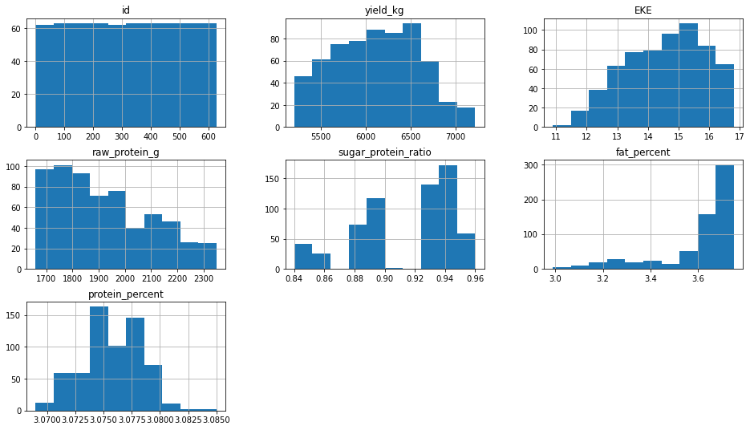

```python
display(df1.head())
display(df2.head())
display(df3.head())
display(df1.hist(figsize = (16,9)));


df1_orig = df1.copy()
df2_orig = df2.copy()
df3_orig = df3.copy()
```

|  | yield_kg | EKE | raw_protein_g | sugar_protein_ratio | fat_percent | protein_percent |
| --- | --- | --- | --- | --- | --- | --- |
| yield_kg | 1.000000 | 0.765144 | 0.437543 | 0.787904 | 0.688506 | -0.005701 |
| EKE | 0.765144 | 1.000000 | 0.384747 | 0.741962 | 0.686973 | -0.013321 |
| raw_protein_g | 0.437543 | 0.384747 | 1.000000 | 0.485890 | 0.392822 | 0.229051 |
| sugar_protein_ratio | 0.787904 | 0.741962 | 0.485890 | 1.000000 | 0.701044 | 0.109924 |
| fat_percent | 0.688506 | 0.686973 | 0.392822 | 0.701044 | 1.000000 | 0.043125 |
| protein_percent | -0.005701 | -0.013321 | 0.229051 | 0.109924 | 0.043125 | 1.000000 |

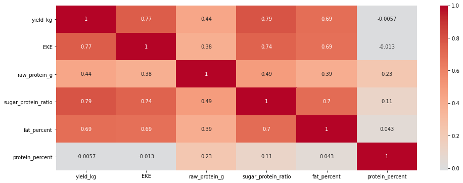

```python
# Вывод коэффициентов корреляции столбцов df1 - только численный

display(df1.drop(['id'], axis = 1).corr(method='spearman'))
plt.figure(figsize=(16, 6))
sns.heatmap(df1.drop(['id'], axis = 1).corr(method='spearman'), annot=True, cmap='coolwarm', center=0)
plt.show()
```

```
interval columns not set, guessing: ['yield_kg', 'EKE', 'raw_protein_g', 'sugar_protein_ratio', 'fat_percent', 'protein_percent']
```

|  | yield_kg | EKE | raw_protein_g | sugar_protein_ratio | breed | grassland_type | dad_breed | fat_percent | protein_percent | milk_taste | age |
| --- | --- | --- | --- | --- | --- | --- | --- | --- | --- | --- | --- |
| yield_kg | 1.000000 | 0.719239 | 0.465118 | 0.661615 | 0.161643 | 0.265755 | 0.442789 | 0.706516 | 0.063045 | 0.178281 | 0.998071 |
| EKE | 0.719239 | 1.000000 | 0.458283 | 0.591190 | 0.123086 | 0.111777 | 0.131868 | 0.715914 | 0.000000 | 0.272265 | 0.771596 |
| raw_protein_g | 0.465118 | 0.458283 | 1.000000 | 0.386550 | 0.090971 | 0.089207 | 0.000000 | 0.397691 | 0.202386 | 0.173817 | 0.353829 |
| sugar_protein_ratio | 0.661615 | 0.591190 | 0.386550 | 1.000000 | 0.062660 | 0.232757 | 0.446655 | 0.645581 | 0.073787 | 0.572702 | 0.744410 |
| breed | 0.161643 | 0.123086 | 0.090971 | 0.062660 | 1.000000 | 0.084197 | 0.035002 | 0.222825 | 0.361851 | 0.000000 | 0.057295 |
| grassland_type | 0.265755 | 0.111777 | 0.089207 | 0.232757 | 0.084197 | 1.000000 | 0.597325 | 0.012454 | 0.158844 | 0.104132 | 0.066703 |
| dad_breed | 0.442789 | 0.131868 | 0.000000 | 0.446655 | 0.035002 | 0.597325 | 1.000000 | 0.271409 | 0.116110 | 0.000000 | 0.150939 |
| fat_percent | 0.706516 | 0.715914 | 0.397691 | 0.645581 | 0.222825 | 0.012454 | 0.271409 | 1.000000 | 0.000000 | 0.198793 | 0.677913 |
| protein_percent | 0.063045 | 0.000000 | 0.202386 | 0.073787 | 0.361851 | 0.158844 | 0.116110 | 0.000000 | 1.000000 | 0.143857 | 0.000000 |
| milk_taste | 0.178281 | 0.272265 | 0.173817 | 0.572702 | 0.000000 | 0.104132 | 0.000000 | 0.198793 | 0.143857 | 1.000000 | 0.165974 |
| age | 0.998071 | 0.771596 | 0.353829 | 0.744410 | 0.057295 | 0.066703 | 0.150939 | 0.677913 | 0.000000 | 0.165974 | 1.000000 |

```
interval columns not set, guessing: ['yield_kg', 'EKE', 'raw_protein_g', 'sugar_protein_ratio', 'fat_percent', 'protein_percent']
```

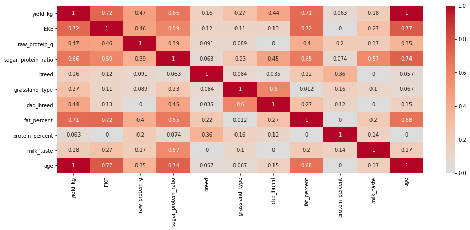

```python
display(df1.drop(['id'], axis = 1).phik_matrix())

plt.figure(figsize=(16, 6))
sns.heatmap(df1.drop(['id'], axis = 1).phik_matrix(), annot=True, cmap='coolwarm', center=0)
plt.show()
```

```
Коэффициент корреляции и p_value EKE и yield_kg: 0.7651443116006692 8.359783320590403e-122
```

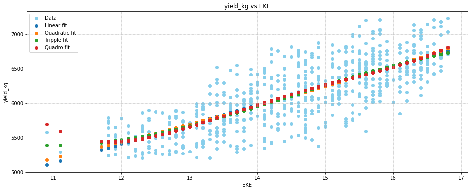

```
Коэффициент корреляции и p_value raw_protein_g и yield_kg: 0.43754251989802084 9.395930002891475e-31
```

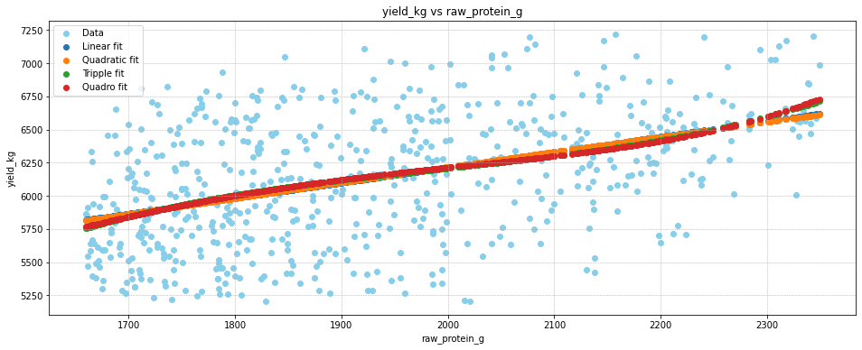

```
Коэффициент корреляции и p_value sugar_protein_ratio и yield_kg: 0.7879040908519489 6.236376891917409e-134
```

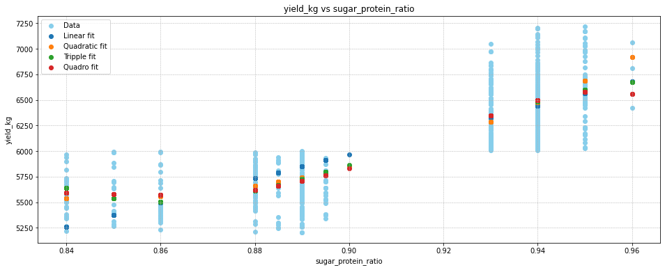

```
Коэффициент корреляции и p_value fat_percent и yield_kg: 0.688505794761783 2.1035311214189552e-89
```

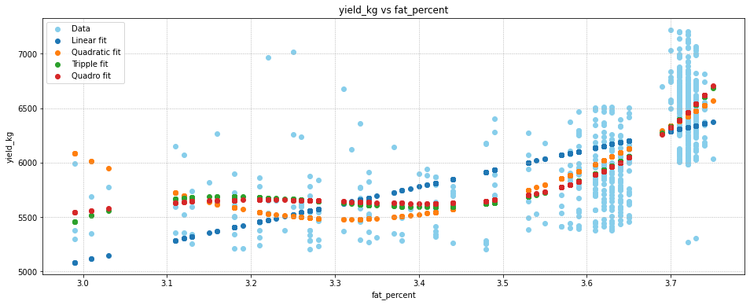

```
Коэффициент корреляции и p_value protein_percent и yield_kg: -0.0057008813839627215 0.8866217252042491
```

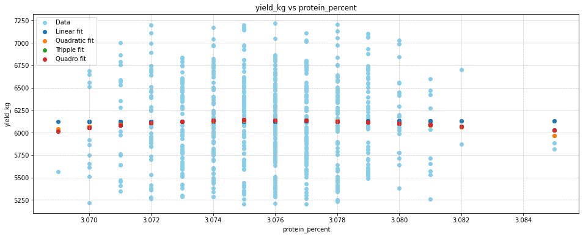

```python
for col in df1.columns:
    if (str(df1[col][0])[0].isdigit()) and (col != 'id')and (col != 'yield_kg'):

        correlation, p_value = spearmanr(df1[col], df1['yield_kg'])
        print(f'Коэффициент корреляции и p_value {col} и yield_kg:', correlation, p_value)


        coefficients = np.polyfit(df1[col], df1['yield_kg'], 1)
        y1 = np.polyval(coefficients, df1[col])

        coefficients = np.polyfit(df1[col], df1['yield_kg'], 2)
        y2 = np.polyval(coefficients, df1[col])

        coefficients = np.polyfit(df1[col], df1['yield_kg'], 3)
        y3 = np.polyval(coefficients, df1[col])

        coefficients = np.polyfit(df1[col], df1['yield_kg'], 4)
        y4 = np.polyval(coefficients, df1[col])



        plt.figure(figsize=(16, 6))

        plt.title(f'yield_kg vs {col}')
        plt.xlabel(col)
        plt.ylabel('yield_kg')
        plt.grid(True, which='both', linestyle='--', linewidth=0.5)
        plt.scatter(x = df1[col], y = df1['yield_kg'], color='skyblue', label = 'Data')
        plt.scatter(x = df1[col], y = y1, label = 'Linear fit')
        plt.scatter(x = df1[col], y = y2, label = 'Quadratic fit')
        plt.scatter(x = df1[col], y = y3, label = 'Tripple fit')
        plt.scatter(x = df1[col], y = y4, label = 'Quadro fit')
        plt.legend(loc='upper left')
        plt.show()
```

Как правило, о мультиколлинеарности говорят при значении коэффициента корреляции от 0.9 до 0.95 по модулю. В df1 таких значений между входными количественными параметрами не найдено. Между yield_kg и protein_percent присутствует очень слабая корреляция.

Установлена сильная корреляция между yield_kg и категориальным параметром age.

Взаимосвязь между yield_kg и EKE, sugar_protein_ratio линейно описывается хуже, нежели квадратично. Хотя квадратичная функция также не в полной мере "фитит" данные.

Между milk_taste и breed, dad_breed коэффициент корреляции 0. Их можно исключить из рассмотрения при опредлении milk_taste.

#### Вывод

Проведен корреляционный анализ данных, выявлены корреляционные коэффициенты и нелинейности между признаками.

## Обучение модели линейной регрессии

```python
df1.columns
```

```
Index(['id', 'yield_kg', 'EKE', 'raw_protein_g', 'sugar_protein_ratio',
       'breed', 'grassland_type', 'dad_breed', 'fat_percent',
       'protein_percent', 'milk_taste', 'age'],
      dtype='object')
```

#### Модель 1

Добавил параметр возраста

```python
y = df1['yield_kg']
num_col = ['EKE', 'raw_protein_g', 'sugar_protein_ratio']
cat_col = ['breed', 'grassland_type', 'dad_breed', 'age']
X = df1[num_col + cat_col]


X_train, X_test, y_train, y_test = train_test_split(X, y, random_state=42)


scaler_1 = StandardScaler()
X_train_num = scaler_1.fit_transform(X_train[num_col])
X_test_num = scaler_1.transform(X_test[num_col])
X_train_num_df = pd.DataFrame(X_train_num, columns=num_col)
X_test_num_df = pd.DataFrame(X_test_num, columns=num_col)


encoder_1 = OneHotEncoder(drop='first')
X_train_cat = encoder_1.fit_transform(X_train[cat_col]).toarray()
X_test_cat = encoder_1.transform(X_test[cat_col]).toarray()
X_train_cat_df = pd.DataFrame(X_train_cat, columns=encoder_1.get_feature_names(cat_col))
X_test_cat_df = pd.DataFrame(X_test_cat, columns=encoder_1.get_feature_names(cat_col))


X_train_final = pd.concat([X_train_num_df, X_train_cat_df], axis=1)
X_test_final = pd.concat([X_test_num_df, X_test_cat_df], axis=1)


model_1 = LinearRegression()
model_1.fit(X_train_final, y_train)
predictions_1 = model_1.predict(X_test_final)


r2_1 = r2_score(y_test, predictions_1)


residuals_1 = y_test - predictions_1
```

```python
X_test_final_1 = X_test_final
```

```
R2 score Модели 1: 0.8043664892115381
Среднее значение остатков Модели 1: -20.458251599205234
Std значение остатков Модели 1: 198.50840944524427
```

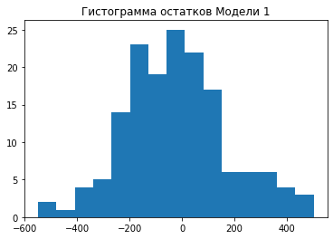

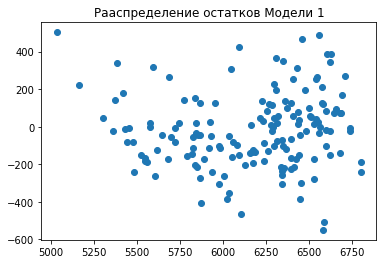

```python
# Гистограмма остатков Модели 1
plt.hist(residuals_1, bins = 15)
plt.title('Гистограмма остатков Модели 1')
print("R2 score Модели 1:", r2_1)
print("Среднее значение остатков Модели 1:", np.mean(residuals_1))
print("Std значение остатков Модели 1:", np.std(residuals_1))
plt.figure()
plt.title('Рааспределение остатков Модели 1')
plt.scatter(x = predictions_1, y = residuals_1)
plt.show()
```

Анализ остатков показал: распредление остатков, похожее на нормальное, небольшое смещение влево и неравномерную диаграмму рассеяния остатков, похожую на рупор.

#### Модель 2

```python
# Обновление данных и модели
y = df1['yield_kg'].copy()

num_col = ['EKE', 'raw_protein_g']
cat_col = ['breed', 'grassland_type', 'dad_breed', 'sugar_protein_ratio', 'age']

X = df1[num_col + cat_col].copy()

# Вводим квадратичную компоненту EKE
X['EKE_sq'] = X['EKE']**2
num_col.append('EKE_sq')

# Преобразуем sugar_protein_ratio в категориальный признак
# Порог 0.91 взят по примерной границе из графика зависимости sugar_protein_ratio vs yield_kg выше
spo_thr = 0.91
X['sugar_protein_ratio'] = np.where(X['sugar_protein_ratio'] < spo_thr, 0, 1)

X_train, X_test, y_train, y_test = train_test_split(X, y, random_state=42)


scaler_2 = StandardScaler()
X_train_num = scaler_2.fit_transform(X_train[num_col])
X_test_num = scaler_2.transform(X_test[num_col])
X_train_num_df = pd.DataFrame(X_train_num, columns=num_col)
X_test_num_df = pd.DataFrame(X_test_num, columns=num_col)



encoder_2 = OneHotEncoder(drop='first')
X_train_cat = encoder_2.fit_transform(X_train[cat_col]).toarray()
X_test_cat = encoder_2.transform(X_test[cat_col]).toarray()
X_train_cat_df = pd.DataFrame(X_train_cat, columns=encoder_2.get_feature_names(cat_col))
X_test_cat_df = pd.DataFrame(X_test_cat, columns=encoder_2.get_feature_names(cat_col))


X_train_final = pd.concat([X_train_num_df, X_train_cat_df], axis=1)
X_test_final = pd.concat([X_test_num_df, X_test_cat_df], axis=1)


model_2 = LinearRegression()
model_2.fit(X_train_final, y_train)
predictions_2 = model_2.predict(X_test_final)


r2_2 = r2_score(y_test, predictions_2)


residuals_2 = y_test - predictions_2
```

```
R2 score Модели 2: 0.8252072642778217
Среднее значение остатков Модели 2: -20.931668561615687
Std значение остатков Модели 2: 187.46610972026357
```

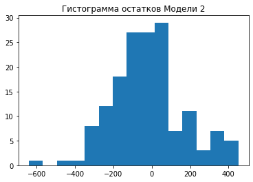

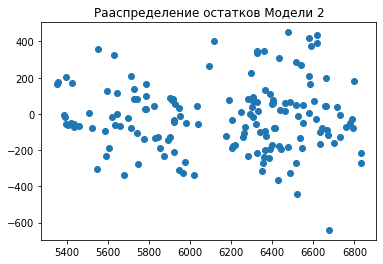

```python
# Гистограмма остатков модели 2
plt.hist(residuals_2, bins = 15)
plt.title('Гистограмма остатков Модели 2')
print("R2 score Модели 2:", r2_2)
print("Среднее значение остатков Модели 2:", np.mean(residuals_2))
print("Std значение остатков Модели 2:", np.std(residuals_2))
plt.figure()
plt.title('Рааспределение остатков Модели 2')
plt.scatter(x = predictions_2, y = residuals_2)
plt.show()
```

Анализ остатков показал: распредление остатков, похожее на нормально, небольшое смещение влево и непостоянную, но более равномерную по сравнению с моделью 1 диаграмму рассеяния остатков.

#### Модель 3

```python
# Смержили df1 и df2 по id параметру, добавили dad_name столбец
df_merged = pd.merge(df1, df2, on='id')
df_merged.head()
```

|  | id | yield_kg | EKE | raw_protein_g | sugar_protein_ratio | breed | grassland_type | dad_breed | fat_percent | protein_percent | milk_taste | age | dad_name |
| --- | --- | --- | --- | --- | --- | --- | --- | --- | --- | --- | --- | --- | --- |
| 0 | 1 | 5863 | 14.2 | 1743 | 0.890 | Вис Бик Айдиал | Равнинное | Айдиал | 3.58 | 3.076 | вкусно | более_2_лет | Буйный |
| 1 | 2 | 5529 | 12.8 | 2138 | 0.890 | Вис Бик Айдиал | Равнинные | Соверин | 3.54 | 3.079 | вкусно | менее_2_лет | Соловчик |
| 2 | 3 | 5810 | 14.0 | 1854 | 0.885 | РефлешнСоверинг | Холмистое | Соверин | 3.59 | 3.074 | не вкусно | более_2_лет | Барин |
| 3 | 4 | 5895 | 12.4 | 2012 | 0.885 | РефлешнСоверинг | Холмистое | Айдиал | 3.40 | 3.075 | не вкусно | более_2_лет | Буйный |
| 4 | 5 | 5302 | 12.8 | 1675 | 0.885 | Вис Бик Айдиал | Равнинные | Соверин | 3.73 | 3.073 | вкусно | менее_2_лет | Барин |

```python
# Обновление данных и модели
y = df_merged['yield_kg'].copy()


num_col = ['EKE', 'raw_protein_g']
cat_col = ['breed', 'grassland_type', 'dad_breed', 'sugar_protein_ratio', 'dad_name', 'age']

X = df_merged[num_col + cat_col].copy()


# Вводим квадратичную компоненту EKE
X['EKE_sq'] = X['EKE']**2
num_col.append('EKE_sq')

# Преобразуем sugar_protein_ratio в категориальный признак
X['sugar_protein_ratio'] = np.where(X['sugar_protein_ratio'] < spo_thr, 0, 1)


X_train, X_test, y_train, y_test = train_test_split(X, y, random_state=42)


scaler_3 = StandardScaler()
X_train_num = scaler_3.fit_transform(X_train[num_col])
X_test_num = scaler_3.transform(X_test[num_col])
X_train_num_df = pd.DataFrame(X_train_num, columns=num_col)
X_test_num_df = pd.DataFrame(X_test_num, columns=num_col)


encoder_3 = OneHotEncoder(drop='first')
X_train_cat = encoder_3.fit_transform(X_train[cat_col]).toarray()
X_test_cat = encoder_3.transform(X_test[cat_col]).toarray()
X_train_cat_df = pd.DataFrame(X_train_cat, columns=encoder_3.get_feature_names(cat_col))
X_test_cat_df = pd.DataFrame(X_test_cat, columns=encoder_3.get_feature_names(cat_col))


X_train_final = pd.concat([X_train_num_df, X_train_cat_df], axis=1)
X_test_final = pd.concat([X_test_num_df, X_test_cat_df], axis=1)


model_3 = LinearRegression()
model_3.fit(X_train_final, y_train)
predictions_3 = model_3.predict(X_test_final)


r2_3 = r2_score(y_test, predictions_3)


residuals_3 = y_test - predictions_3
```

```
R2 score Модели 3: 0.8233264238544057
Среднее значение остатков Модели 3: -16.348429400316206
Std значение остатков Модели 3: 188.93723590809714
```

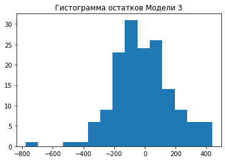

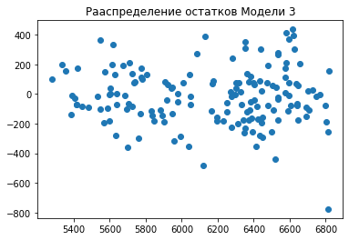

```python
# Гистограмма остатков модели 3
plt.hist(residuals_3, bins = 15)
plt.title('Гистограмма остатков Модели 3')
print("R2 score Модели 3:", r2_3)
print("Среднее значение остатков Модели 3:", np.mean(residuals_3))
print("Std значение остатков Модели 3:", np.std(residuals_3))
plt.figure()
plt.title('Рааспределение остатков Модели 3')
plt.scatter(x = predictions_3, y = residuals_3)
plt.show()
```

Анализ остатков показал: распредление остатков, похожее на нормальное, небольшое смещение влево (меньше, чем предыдущие модели) и неравномерную (сопоставимо с моделью 2) диаграмму рассеяния остатков с одиночным выбросом.

Рассчитываем точность каждой модели по трём метрикам: MSE, MAE, RMSE.

```python
model_list = [model_1, model_2, model_3]
prediction_list = [predictions_1, predictions_2, predictions_3]
counter = 0

for prediction in prediction_list:
    counter +=1
    mae = mean_absolute_error(y_test, prediction)
    mse = mean_squared_error(y_test, prediction)
    rmse = np.sqrt(mse)
    print(f'Model {counter} MAE: {mae}')
    print(f'Model {counter} MSE: {mse}')
    print(f'Model {counter} RMSE: {rmse}')
    print()
```

```
Model 1 MAE: 156.6120117411351
Model 1 MSE: 39824.128678977126
Model 1 RMSE: 199.55983733952363

Model 2 MAE: 146.6840806380439
Model 2 MSE: 35581.67704242323
Model 2 RMSE: 188.63106065127033

Model 3 MAE: 147.46201248284012
Model 3 MSE: 35964.550256449074
Model 3 RMSE: 189.64321832443434
```

Находим доверительный интервал прогноза Модели 2

```python
lower_bound = np.percentile(predictions_2, 2.5)
upper_bound = np.percentile(predictions_2, 97.5)

# Доверительный интервал с вероятностью 95%
confidence_interval = (lower_bound, upper_bound)

print("Доверительный интервал прогноза (95% вероятность):", confidence_interval)
```

```
Доверительный интервал прогноза (95% вероятность): (5394.22922595786, 6791.441780076087)
```

#### Прогноз удоя по Cow buy

Применяем лучшую по качеству и по точности модель (Модель 2) к данным из датасета cow_buy.csv и спрогнозируем удой коров, которых фермер хочет купить.

```python
# Получаем расчетные параметры корма согласно прогнозу
EKE_forecast = ((df1['EKE'].mean())*1.05)
sugar_protein_ratio_forecast = ((df1['sugar_protein_ratio'].mean())*1.05)
raw_protein_g_forecast = ((df1['raw_protein_g'].mean())*1.05)


df3['EKE'] = EKE_forecast
df3['sugar_protein_ratio'] = sugar_protein_ratio_forecast
df3['raw_protein_g'] = raw_protein_g_forecast


num_col = ['EKE', 'raw_protein_g']
cat_col = ['breed', 'grassland_type', 'dad_breed', 'sugar_protein_ratio', 'age']

X = df3[num_col + cat_col].copy()


# Вводим квадратичную компоненту EKE
X['EKE_sq'] = X['EKE']**2
num_col.append('EKE_sq')

# Преобразуем sugar_protein_ratio в категориальный признак
X['sugar_protein_ratio'] = np.where(X['sugar_protein_ratio'] < spo_thr, 0, 1)


X['grassland_type'] = X['grassland_type'].replace({'равнинное': 'Равнинное', 'холмистое': 'Холмистое'})


X_test_num = scaler_2.transform(X[num_col])
X_test_num_df = pd.DataFrame(X_test_num, columns=num_col)
X_test_cat = encoder_2.transform(X[cat_col]).toarray()
X_test_cat_df = pd.DataFrame(X_test_cat, columns=encoder_2.get_feature_names(cat_col))
X_test_final = pd.concat([X_test_num_df, X_test_cat_df], axis=1)


predictions_4 = model_2.predict(X_test_final)
```

Веса Модели 2

```python
coefficients = pd.DataFrame({
    'Feature': X_test_final.columns,
    'Coefficient': model_2.coef_
})

print(coefficients)
```

```
                    Feature  Coefficient
0                       EKE -1018.895189
1             raw_protein_g    43.719134
2                    EKE_sq  1167.635240
3     breed_РефлешнСоверинг     1.796936
4  grassland_type_Равнинные   -81.749106
5  grassland_type_Холмистое    28.625229
6         dad_breed_Айдиалл  -103.913152
7         dad_breed_Соверин  -246.570784
8     sugar_protein_ratio_1   377.805357
9           age_менее_2_лет  -250.907971
```

```python
yield_result = pd.DataFrame(predictions_4)
yield_result.columns = ['yield_kg_forecast']
yield_result
```

|  | yield_kg_forecast |
| --- | --- |
| 0 | 6558.471097 |
| 1 | 6032.367114 |
| 2 | 6285.072020 |
| 3 | 6560.268033 |
| 4 | 6531.642804 |
| 5 | 6034.164049 |
| 6 | 6558.471097 |
| 7 | 6283.275085 |
| 8 | 6285.072020 |
| 9 | 6309.360062 |
| 10 | 6311.900313 |
| 11 | 6285.072020 |
| 12 | 6558.471097 |
| 13 | 6060.992343 |
| 14 | 6285.072020 |
| 15 | 6560.268033 |
| 16 | 6311.900313 |
| 17 | 6034.164049 |
| 18 | 6283.275085 |
| 19 | 6531.642804 |

#### Вывод

Обучены модели линейной регрессии. На основе лучшей модели получен прогноз удоя молока.

## Обучение модели логистической регрессии

```python
df1.columns
```

```
Index(['id', 'yield_kg', 'EKE', 'raw_protein_g', 'sugar_protein_ratio',
       'breed', 'grassland_type', 'dad_breed', 'fat_percent',
       'protein_percent', 'milk_taste', 'age'],
      dtype='object')
```

Для целевого признака milk_taste из входных признаков убираем breed и dad_breed по результатам корреляционного анализа. Также исходя из общих соображений убираем id, поскольку номер коровы не должен влиять на вкус молока.

```python
# Целевой признак вкус молока
y = df1['milk_taste'].copy()
condition = df1['milk_taste'] == 'вкусно'
y = np.where(condition, 1, 0)


num_col = ['yield_kg', 'EKE', 'raw_protein_g', 'fat_percent', 'protein_percent', 'sugar_protein_ratio']
cat_col = ['grassland_type', 'age']


X = df1[num_col + cat_col]


X_train, X_test, y_train, y_test = train_test_split(X, y, random_state=42)
scaler_cl = StandardScaler()
X_train_num = scaler_cl.fit_transform(X_train[num_col])
X_test_num = scaler_cl.transform(X_test[num_col])
X_train_num_df = pd.DataFrame(X_train_num, columns=num_col)
X_test_num_df = pd.DataFrame(X_test_num, columns=num_col)


encoder_cl = OneHotEncoder(drop='first')
X_train_cat = encoder_cl.fit_transform(X_train[cat_col]).toarray()
X_test_cat = encoder_cl.transform(X_test[cat_col]).toarray()
X_train_cat_df = pd.DataFrame(X_train_cat, columns=encoder_cl.get_feature_names(cat_col))
X_test_cat_df = pd.DataFrame(X_test_cat, columns=encoder_cl.get_feature_names(cat_col))


X_train_final = pd.concat([X_train_num_df, X_train_cat_df], axis=1)
X_test_final = pd.concat([X_test_num_df, X_test_cat_df], axis=1)


model_cl = LogisticRegression()
model_cl.fit(X_train_final, y_train)
predictions_cl = model_cl.predict(X_test_final)
```

```
Accuracy: 0.643312101910828
Precision: 0.6311475409836066
Recall: 0.875
```

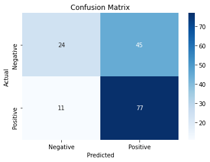

```python
accuracy = accuracy_score(y_test, predictions_cl)
print("Accuracy:", accuracy)

# Расчет метрики precision
precision = precision_score(y_test, predictions_cl)
print("Precision:", precision)

# Расчет метрики recall
recall = recall_score(y_test, predictions_cl)
print("Recall:", recall)

# Расчет метрики матрицы ошибок
conf_matrix = confusion_matrix(y_test, predictions_cl)

labels = ['Negative', 'Positive']

plt.figure(figsize=(6, 4))
sns.heatmap(conf_matrix, annot=True, fmt='g', cmap='Blues',
            xticklabels=labels, yticklabels=labels)
plt.xlabel('Predicted')
plt.ylabel('Actual')
plt.title('Confusion Matrix')
plt.show()
```

```python
# Веса входных параметров
for feature_number, feature_name in enumerate(X_train.columns):
    weight = model_cl.coef_[0, feature_number]
    print(f"{feature_name:<20}: {weight:+.6f}")
```

```
yield_kg            : -0.510857
EKE                 : +0.472615
raw_protein_g       : +0.119148
fat_percent         : -0.119128
protein_percent     : +0.211209
sugar_protein_ratio : +0.400917
grassland_type      : -0.036290
age                 : +0.599527
```

Precision показывает, какую долю из всех объектов, которые модель классифицировала как положительные, действительно являются положительными. В нашем случае, это самая критичная метрика с точки зрения вкуса молока, так как заказчик хочет иметь только вкусное молоко (отсутствие ложно-положительных). Метрику Precision надо максимизировать.

Со стандартным порогом 0.5 модель совершила 45 ложно-положительных и 77 верных положительных предсказаний, что отражает метрика Precision = 0.63.

```
Precision max: 0.875
Threshold: 0.8
Recall: 0.07954545454545454
```

[output not shown]

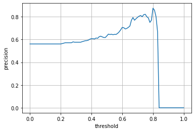

```python
threshold = np.linspace(0, 1, num=101)

true_labels = y_test
predicted_probabilities = model_cl.predict_proba(X_test_final)[:,1]
precision_graph = []


precision_max = 0
thr_max = 0
recall_max = 0

for thr in threshold:
    predicted_labels = [1 if prob >= thr else 0 for prob in predicted_probabilities]
    precision = precision_score(true_labels, predicted_labels)
    precision_graph.append(precision)
    recall = recall_score(true_labels, predicted_labels)
    if precision > precision_max:
        precision_max = precision
        thr_max = thr
        recall_max = recall

print("Precision max:", precision_max);
print('Threshold:', thr_max);
print("Recall:", recall_max);
print()

plt.plot(threshold, precision_graph);
plt.xlabel('threshold');
plt.ylabel('precision');
plt.grid(True);

thr = 0.71
```

Выбираем порог классификации 0.71, чтобы добиться 0.8 precision метрики. При этом recall составит 0.375.

Попробуем добавить dad_name из df2 в качестве дополнительного входного параметра

```python
# Смержили df1 и df2 по id параметру, добавили dad_name столбец
df_merged_cl = pd.merge(df1, df2, on='id')
df_merged_cl.head()
```

|  | id | yield_kg | EKE | raw_protein_g | sugar_protein_ratio | breed | grassland_type | dad_breed | fat_percent | protein_percent | milk_taste | age | dad_name |
| --- | --- | --- | --- | --- | --- | --- | --- | --- | --- | --- | --- | --- | --- |
| 0 | 1 | 5863 | 14.2 | 1743 | 0.890 | Вис Бик Айдиал | Равнинное | Айдиал | 3.58 | 3.076 | вкусно | более_2_лет | Буйный |
| 1 | 2 | 5529 | 12.8 | 2138 | 0.890 | Вис Бик Айдиал | Равнинные | Соверин | 3.54 | 3.079 | вкусно | менее_2_лет | Соловчик |
| 2 | 3 | 5810 | 14.0 | 1854 | 0.885 | РефлешнСоверинг | Холмистое | Соверин | 3.59 | 3.074 | не вкусно | более_2_лет | Барин |
| 3 | 4 | 5895 | 12.4 | 2012 | 0.885 | РефлешнСоверинг | Холмистое | Айдиал | 3.40 | 3.075 | не вкусно | более_2_лет | Буйный |
| 4 | 5 | 5302 | 12.8 | 1675 | 0.885 | Вис Бик Айдиал | Равнинные | Соверин | 3.73 | 3.073 | вкусно | менее_2_лет | Барин |

```python
# Целевой признак вкус молока
y = df_merged_cl['milk_taste'].copy()
condition = df_merged_cl['milk_taste'] == 'вкусно'
y = np.where(condition, 1, 0)


num_col = ['yield_kg', 'EKE', 'raw_protein_g', 'fat_percent', 'protein_percent', 'sugar_protein_ratio']
cat_col = ['grassland_type', 'dad_name', 'age']


X = df_merged_cl[num_col + cat_col]


X_train, X_test, y_train, y_test = train_test_split(X, y, random_state=42)
scaler_cl = StandardScaler()
X_train_num = scaler_cl.fit_transform(X_train[num_col])
X_test_num = scaler_cl.transform(X_test[num_col])
X_train_num_df = pd.DataFrame(X_train_num, columns=num_col)
X_test_num_df = pd.DataFrame(X_test_num, columns=num_col)


encoder_cl = OneHotEncoder(drop='first')
X_train_cat = encoder_cl.fit_transform(X_train[cat_col]).toarray()
X_test_cat = encoder_cl.transform(X_test[cat_col]).toarray()
X_train_cat_df = pd.DataFrame(X_train_cat, columns=encoder_cl.get_feature_names(cat_col))
X_test_cat_df = pd.DataFrame(X_test_cat, columns=encoder_cl.get_feature_names(cat_col))


X_train_final = pd.concat([X_train_num_df, X_train_cat_df], axis=1)
X_test_final = pd.concat([X_test_num_df, X_test_cat_df], axis=1)


model_cl = LogisticRegression()
model_cl.fit(X_train_final, y_train)
predictions_cl = model_cl.predict(X_test_final)
```

```
Accuracy: 0.643312101910828
Precision: 0.626984126984127
Recall: 0.8977272727272727
```

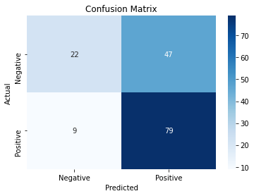

```python
accuracy = accuracy_score(y_test, predictions_cl)
print("Accuracy:", accuracy)

# Расчет метрики precision
precision = precision_score(y_test, predictions_cl)
print("Precision:", precision)

# Расчет метрики recall
recall = recall_score(y_test, predictions_cl)
print("Recall:", recall)

# Расчет метрики матрицы ошибок
conf_matrix = confusion_matrix(y_test, predictions_cl)

labels = ['Negative', 'Positive']

plt.figure(figsize=(6, 4))
sns.heatmap(conf_matrix, annot=True, fmt='g', cmap='Blues',
            xticklabels=labels, yticklabels=labels)
plt.xlabel('Predicted')
plt.ylabel('Actual')
plt.title('Confusion Matrix')
plt.show()
```

Метрики Accuracy, Precision и Recall слабо изменились после обновления входных данных и модели.

```python
for feature_number, feature_name in enumerate(X_train.columns):
    weight = model_cl.coef_[0, feature_number]
    print(f"{feature_name:<20}: {weight:+.6f}")
```

```
yield_kg            : -0.597257
EKE                 : +0.513712
raw_protein_g       : +0.160580
fat_percent         : -0.099355
protein_percent     : +0.204037
sugar_protein_ratio : +0.402599
grassland_type      : -0.014438
dad_name            : +0.591146
age                 : +0.022761
```

Согласно весам модели, вкус молока наследственный, кроме того, на него сильно влияют параметры корма и количество удоя.

```
Precision max: 1.0
Threshold: 0.8200000000000001
Recall: 0.07954545454545454
```

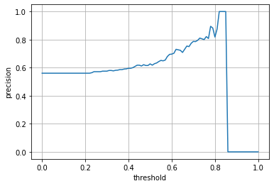

```python
threshold = np.linspace(0, 1, num=101)

true_labels = y_test
predicted_probabilities = model_cl.predict_proba(X_test_final)[:,1]
precision_graph = []


precision_max = 0
thr_max = 0
recall_max = 0

for thr in threshold:
    predicted_labels = [1 if prob >= thr else 0 for prob in predicted_probabilities]
    precision = precision_score(true_labels, predicted_labels)
    precision_graph.append(precision)
    recall = recall_score(true_labels, predicted_labels)
    if precision > precision_max:
        precision_max = precision
        thr_max = thr
        recall_max = recall

print("Precision max:", precision_max)
print('Threshold:', thr_max)
print("Recall:", recall_max)
print()


plt.plot(threshold, precision_graph)
plt.xlabel('threshold')
plt.ylabel('precision')
plt.grid(True)

thr = 0.78
```

#### Прогноз вкуса по cow buy

```python
X = df3.copy()


X['grassland_type'] = X['grassland_type'].replace({'равнинное': 'Равнинное', 'холмистое': 'Холмистое'})

X['yield_kg'] = yield_result.copy()


num_col = ['yield_kg', 'EKE', 'raw_protein_g', 'current_fat_percent',
       'current_protein_percent', 'sugar_protein_ratio']

cat_col = ['grassland_type', 'dad_name', 'age']


X_test_num = scaler_cl.transform(X[num_col])
X_test_num_df = pd.DataFrame(X_test_num, columns=num_col)

X_test_cat = encoder_cl.transform(X[cat_col]).toarray()
X_test_cat_df = pd.DataFrame(X_test_cat, columns=encoder_cl.get_feature_names(cat_col))

X_test_final = pd.concat([X_test_num_df, X_test_cat_df], axis=1)


predictions_5 = model_cl.predict(X_test_final)
```

```python
predicted_probabilities = model_cl.predict_proba(X_test_final)[:,1]
predicted_labels = [1 if prob >= thr else 0 for prob in predicted_probabilities]
predicted_labels
```

```
[1, 1, 0, 0, 0, 0, 1, 1, 0, 1, 0, 0, 0, 1, 0, 0, 1, 0, 0, 0]
```

Модель дала прогноз относительно вкуса молока на основании данных датафрейма cow buy.

#### Вывод

Обучены модели логистической регрессии для получения прогноза вкуса молока.

## Итоговые выводы

Составим датафрейм df_final с прогнозами удоя и вкуса молока

```python
df_final = pd.DataFrame()
df_final['yield_kg'] = pd.Series(predictions_4)
df_final['milk_taste'] = pd.Series(predicted_labels)
df_final['taste_probability'] = pd.Series(predicted_probabilities)

df_final
```

|  | yield_kg | milk_taste | taste_probability |
| --- | --- | --- | --- |
| 0 | 6558.471097 | 1 | 0.794217 |
| 1 | 6032.367114 | 1 | 0.808412 |
| 2 | 6285.072020 | 0 | 0.703460 |
| 3 | 6560.268033 | 0 | 0.556070 |
| 4 | 6531.642804 | 0 | 0.634587 |
| 5 | 6034.164049 | 0 | 0.314573 |
| 6 | 6558.471097 | 1 | 0.794217 |
| 7 | 6283.275085 | 1 | 0.785045 |
| 8 | 6285.072020 | 0 | 0.703460 |
| 9 | 6309.360062 | 1 | 0.834007 |
| 10 | 6311.900313 | 0 | 0.356922 |
| 11 | 6285.072020 | 0 | 0.683735 |
| 12 | 6558.471097 | 0 | 0.254163 |
| 13 | 6060.992343 | 1 | 0.827918 |
| 14 | 6285.072020 | 0 | 0.703460 |
| 15 | 6560.268033 | 0 | 0.632015 |
| 16 | 6311.900313 | 1 | 0.786695 |
| 17 | 6034.164049 | 0 | 0.296828 |
| 18 | 6283.275085 | 0 | 0.655564 |
| 19 | 6531.642804 | 0 | 0.634587 |

```python
df_final_qualified = df_final[(df_final['yield_kg'] >= 6000) & (df_final['milk_taste'] == 1)]
display(df_final_qualified)
print('Количество коров с вкусным молоком и удоем более 6000 кг в год, рекомендуемых к покупке:', len(df_final_qualified))
```

|  | yield_kg | milk_taste | taste_probability |
| --- | --- | --- | --- |
| 0 | 6558.471097 | 1 | 0.794217 |
| 1 | 6032.367114 | 1 | 0.808412 |
| 6 | 6558.471097 | 1 | 0.794217 |
| 7 | 6283.275085 | 1 | 0.785045 |
| 9 | 6309.360062 | 1 | 0.834007 |
| 13 | 6060.992343 | 1 | 0.827918 |
| 16 | 6311.900313 | 1 | 0.786695 |

```
Количество коров с вкусным молоком и удоем более 6000 кг в год, рекомендуемых к покупке: 7
```

Согласно заданным критериям можно приобретать коров №0, 1, 6, 7, 9, 13, 16 у ЭкоФермы, т.к. согласно прогнозу они будут приносить более 6000 кг удоя в год и иметь хороший вкус. Надо помнить, что прогноз основывается на улучшении показателей корма на 5%, относительно средних значений. Также для лучшего понимания в датафрейм df_final добавлен столбец taste_probability, который содержит вероятности классификации молока коровы как молока с хорошим вкусом.

Согласно весам модели линейной регрессии, на удой значимо влияют параметр энергетической питательности корма и сахарно-протеиновое отношение. Если можно контролировать эти параметры корма, то удастся увеличивать удой.

Согласно весам логистической модели, на вкус влияют параметры корма сахарно-протеиновое отношение и ЭКЕ, а также отрицательно влияет удой. Возможно, это можно контролировать и получать вкусное молоко у большего количества коров.

Для улучшения результатов работы моделей были созданы новые входные параметры на основании уже существующих, а также исключены те, которые не мешали работе модели.

Для дальнейшего улучшения работы модели можно было бы перебрать еще большее количество синтетических входных параметров для компенсации нелинейности их взаимосвязи с целевым параметром.

Также дополнительные новые входные параметры и увеличение датасетов могли бы помочь улучшить работу моделей.